# J381M_H04_nlp

Shengchun Huang

# Objectives

Welcome back to J381M!

In this tutorial, we will move beyond standard numerical data and learn how to process unstructured text data. This field is broadly known as Natural Language Processing (NLP) or Computational Text Analysis.

Why do we need NLP? The vast majority of human-generated data (social media posts, news articles, open-ended survey responses) exists as text, not numbers. Computers cannot inherently “read” language, so we must learn techniques to convert words into mathematical structures. This allows us to quantify sentiment, discover hidden themes, and scale our analysis from reading 10 posts to analyzing 10,000. (Also, LLMs like ChatGPT are built on NLP techniques!)

NLP is a big topic, so today we will focus on the basics of text processing and some common analysis techniques. For extended learning, I recommend the book [“Text Mining with R” by Julia Silge and David Robinson (available free online).](https://www.tidytextmining.com/) and Text as Data: A New Framework for Machine Learning and the Social Sciences by Justin Grimmer, Margaret E. Roberts, and Brandon M. Stewart (accessible via the UT library).

Content of today:

0. Set-up:
   - Start a new R script in R studio in your j381m project folder and clean the environment before you start (use `rm = list (ls())`)
   - Install and library required packages
   - Read the data (Make sure the practice sample dataset is in the same folder)
1. Processing the text data:
   - Tokenization: Breaking long strings of text (sentences) into individual units (words).
   - Cleaning: Removing “stop words” (common words like “the”, “and”, “is”) that often do not add semantic value.
   - Standardization: Converting text to lower case and handling special characters.
2. Text Analysis:
   - Descriptive analysis (Exercise: counting word frequency)
   - Sentiment analysis (Exercise: how do we quantify emotion in text?)
   - Topic modeling (Exercise: discovering hidden topics using LDA and STM in a corpus)

# Set up the environment

```r
# Install and load required packages
library(tidyverse)    # For data manipulation and plotting
library(tidytext)     # For text mining tools
library(topicmodels)  # For LDA topic modeling
library(stm)          # For Structural Topic Modeling
library(ggplot2)      # For enhanced plotting
library(wordcloud)    # For creating a word cloud
library(textdata)    # For sentiment analysis lexicons
library(reshape2)      # For data reshaping

# a trick to use multiple packages together:
if(!require('pacman')) {install.packages('pacman')}
pacman::p_load(tidyverse, tidytext, topicmodels, stm, ggplot2, wordcloud, textdata, reshape2)

# Read the data
raw_data <- read_csv("exercise_data_reddit_inflation_political.csv")

#let's take a look at the data (you can also click it in the environment to view as a table)
head(raw_data)
```

```
## # A tibble: 6 × 61
##   id    title thumbnail selftext created_utc author author_created_utc banned_by
##   <chr> <chr> <chr>     <chr>          <dbl> <chr>               <dbl> <lgl>
## 1 x7z2… 3 ti… default   <NA>      1662537145 rajac…         1655633746 NA
## 2 x7z9… 3 ti… default   <NA>      1662537806 lates…         1655604798 NA
## 3 x809… UK’s… default   <NA>      1662541755 rajac…         1655633746 NA
## 4 x90x… Dow … default   <NA>      1662644718 rajac…         1655633746 NA
## 5 xbib… This… default   <NA>      1662902183 rajac…         1655633746 NA
## 6 xcww… Ted … default   [delete…  1663040205 [dele…                 NA NA
## # ℹ 53 more variables: can_mod_post <lgl>, category <lgl>,
## #   content_categories <lgl>, archived <lgl>, discussion_type <lgl>,
## #   distinguished <lgl>, domain <chr>, edited <lgl>, gilded <dbl>,
## #   hidden <lgl>, hide_score <lgl>, is_created_from_ads_ui <lgl>,
## #   is_crosspostable <lgl>, is_meta <lgl>, is_original_content <lgl>,
## #   is_reddit_media_domain <lgl>, is_self <lgl>, is_video <lgl>, locked <lgl>,
## #   media_only <lgl>, name <chr>, no_follow <lgl>, num_comments <dbl>, …
```

```r
str(raw_data)
```

```
## spc_tbl_ [943 × 61] (S3: spec_tbl_df/tbl_df/tbl/data.frame)
##  $ id                     : chr [1:943] "x7z2ps" "x7z9d0" "x809nd" "x90xla" ...
##  $ title                  : chr [1:943] "3 tips to consider when buying essential items during high inflation, contentonly to experts" "3 tips to consider when buying essential items during high inflation, contentonly to experts" "UK’s broadband firms set for £1.7bn windfall with above-inflation …
##  $ thumbnail              : chr [1:943] "default" "default" "default" "default" ...
##  $ selftext               : chr [1:943] NA NA NA NA ...
##  $ created_utc            : num [1:943] 1.66e+09 1.66e+09 1.66e+09 1.66e+09 1.66e+09 ...
##  $ author                 : chr [1:943] "rajacreator" "latestasianews" "rajacreator" "rajacreator" ...
##  $ author_created_utc     : num [1:943] 1.66e+09 1.66e+09 1.66e+09 1.66e+09 1.66e+09 ...
##  $ banned_by              : logi [1:943] NA NA NA NA NA NA ...
##  $ can_mod_post           : logi [1:943] FALSE FALSE FALSE FALSE FALSE FALSE ...
##  $ category               : logi [1:943] NA NA NA NA NA NA ...
##  $ content_categories     : logi [1:943] NA NA NA NA NA NA ...
##  $ archived               : logi [1:943] FALSE FALSE FALSE FALSE FALSE FALSE ...
##  $ discussion_type        : logi [1:943] NA NA NA NA NA NA ...
##  $ distinguished          : logi [1:943] NA NA NA NA NA NA ...
##  $ domain                 : chr [1:943] "rajacreator.com" "rajacreator.com" "rajacreator.com" "rajacreator.com" ...
##  $ edited                 : logi [1:943] FALSE FALSE FALSE FALSE FALSE FALSE ...
##  $ gilded                 : num [1:943] 0 0 0 0 0 0 0 0 0 0 ...
##  $ hidden                 : logi [1:943] FALSE FALSE FALSE FALSE FALSE FALSE ...
##  $ hide_score             : logi [1:943] FALSE FALSE FALSE FALSE FALSE FALSE ...
##  $ is_created_from_ads_ui : logi [1:943] FALSE FALSE FALSE FALSE FALSE FALSE ...
##  $ is_crosspostable       : logi [1:943] FALSE FALSE FALSE FALSE FALSE FALSE ...
##  $ is_meta                : logi [1:943] FALSE FALSE FALSE FALSE FALSE FALSE ...
##  $ is_original_content    : logi [1:943] FALSE FALSE FALSE FALSE FALSE FALSE ...
##  $ is_reddit_media_domain : logi [1:943] FALSE FALSE FALSE FALSE FALSE FALSE ...
##  $ is_self                : logi [1:943] FALSE FALSE FALSE FALSE FALSE FALSE ...
##  $ is_video               : logi [1:943] FALSE FALSE FALSE FALSE FALSE FALSE ...
##  $ locked                 : logi [1:943] FALSE FALSE FALSE FALSE FALSE FALSE ...
##  $ media_only             : logi [1:943] FALSE FALSE FALSE FALSE FALSE FALSE ...
##  $ name                   : chr [1:943] "t3_x7z2ps" "t3_x7z9d0" "t3_x809nd" "t3_x90xla" ...
##  $ no_follow              : logi [1:943] TRUE TRUE TRUE TRUE TRUE FALSE ...
##  $ num_comments           : num [1:943] 0 2 0 0 0 2 13 19 0 1 ...
##  $ num_crossposts         : num [1:943] 0 0 0 0 0 0 0 0 0 0 ...
##  $ over_18                : logi [1:943] FALSE FALSE FALSE FALSE FALSE FALSE ...
##  $ parent_whitelist_status: chr [1:943] "all_ads" "all_ads" "all_ads" "all_ads" ...
##  $ permalink              : chr [1:943] "/r/news/comments/x7z2ps/3_tips_to_consider_when_buying_essential_items/" "/r/politics/comments/x7z9d0/3_tips_to_consider_when_buying_essential_items/" "/r/news/comments/x809nd/uks_broadband_firms_set_for_17bn_windfall_with/" "/r/news/comments/x90xla/dow_dr…
##  $ pinned                 : logi [1:943] FALSE FALSE FALSE FALSE FALSE FALSE ...
##  $ quarantine             : logi [1:943] FALSE FALSE FALSE FALSE FALSE FALSE ...
##  $ removed_by             : logi [1:943] NA NA NA NA NA NA ...
##  $ removed_by_category    : chr [1:943] "reddit" "reddit" "reddit" "reddit" ...
```

[output cut: 72 more lines]

```
##   ..   subreddit_type = col_character(),
##   ..   suggested_sort = col_character(),
##   ..   top_awarded_type = col_logical(),
##   ..   total_awards_received = col_double(),
##   ..   upvote_ratio = col_double(),
##   ..   url_overridden_by_dest = col_character(),
##   ..   view_count = col_logical(),
##   ..   whitelist_status = col_character(),
##   ..   post_hint = col_character(),
##   ..   call_to_action = col_logical(),
##   ..   author_cakeday = col_logical(),
##   ..   crosspost_parent = col_character(),
##   ..   is_gallery = col_logical()
##   .. )
##  - attr(*, "problems")=<externalptr>
```

From the quick look of the data, we can see that the dataset contains Reddit posts about inflation and politics. The main text content to be analyzed for today is saved in the `title` and `selftext` columns.

Now, with the raw data, we can start processing and analyzing the text! As you see, text data is often “unstructured,” meaning it doesn’t come in neat rows and columns like an Excel spreadsheet. To analyze it, we must first clean it and break it down into mathematical objects (counts, probabilities, and matrices).

This process is often called “text processing” or “text wrangling.” Let’s get started!

# Text Processing

Before we can analyze the text, we need to tidy it. This involves three main steps:

- Combine text: We have meaningful text in both the title and selftext columns. We should merge them.
- Tokenization: Breaking sentences into individual words.
- Stop word removal: Removing common words (like “the”, “is”, “and”) that don’t carry specific meaning in the analysis (depending on the specific analysis you are running).

## Extract the text data from raw data

```r
# Combine title and selftext into a single text column
processed_data <- raw_data %>%
  unite(col = "full_text", c(title, selftext), sep = " ", remove = FALSE, na.rm = TRUE)

# what is unite doing here? try ?unite in the console to learn about it.

# now let's view the combined text data
head(processed_data$full_text)
```

```
## [1] "3 tips to consider when buying essential items during high inflation, contentonly to experts"
## [2] "3 tips to consider when buying essential items during high inflation, contentonly to experts"
## [3] "UK’s broadband firms set for £1.7bn windfall with above-inflation price rises"
## [4] "Dow drops 200 points as market sell-off returns on new Powell inflation-fighting pledge"
## [5] "This inflation-protected investment looks attractive now, but you should proceed with caution"
## [6] "Ted Cruz: Dems have no plan for inflation other than to make it worse [deleted]"
```

## Tokenization

Next, we are going to tokenize the text data. Tokenization is the process of breaking down text into smaller units, called tokens. In this case, we will break the text into individual words.

(There are other ways to tokenize text, such as by sentences or phrases, but word tokenization is the most common for basic NLP tasks).

```r
# Tokenize the text data into individual words
tokenized_data <- processed_data %>%
  unnest_tokens(output = word, input = full_text) # unnest_tokens is a function from the tidytext package that helps with tokenization. See R documentation for what their arguments are.

# see what you get from the tokenized_data
head(tokenized_data$word)
```

```
## [1] "3"        "tips"     "to"       "consider" "when"     "buying"
```

```r
# if you take a look at the row numbers before and after tokenization, you will see
nrow(processed_data) # number of rows before tokenization
```

```
## [1] 943
```

```r
nrow(tokenized_data) # number of rows after tokenization
```

```
## [1] 16553
```

```r
# Note that the number of rows has increased significantly after tokenization, as each word in the text now has its own row.
```

## Stop Word Removal

Next, we will remove stop words from the tokenized data. Stop words are common words that do not carry significant meaning in the context of text analysis. Examples include “the”, “is”, “in”, “and”, etc. Removing these words helps to focus on the more meaningful words in the text.

```r
# to remove stop words, we can use the built-in stop words dataset from the tidytext package in this tutorial.
data("stop_words")  # load the stop words dataset

# let's take a look at the stop words dataset
head(stop_words)
```

```
## # A tibble: 6 × 2
##   word      lexicon
##   <chr>     <chr>
## 1 a         SMART
## 2 a's       SMART
## 3 able      SMART
## 4 about     SMART
## 5 above     SMART
## 6 according SMART
```

```r
# Remove stop words from the tokenized data
cleaned_data <- tokenized_data %>%
  anti_join(stop_words, by = "word")  # anti_join keeps only rows that do not have matches in the stop_words dataset

# let's see how many rows we have after removing stop words
nrow(cleaned_data)
```

```
## [1] 9675
```

```r
# you should see a significant reduction in the number of rows after removing stop words!

# an optional move: you might also remove numbers and punctuation if needed
cleaned_data <- cleaned_data %>%
  filter(!str_detect(word, "^[0-9]+$")) %>%
  filter(!str_detect(word, "^[[:punct:]]+$"))

# let's see the cleaned data now:
head(cleaned_data$word) # you can see numbers are also removed if any existed
```

```
## [1] "tips"        "buying"      "essential"   "items"       "inflation"
## [6] "contentonly"
```

```r
nrow(cleaned_data) # also reflected in the row change
```

```
## [1] 9360
```

## Extended Learning: Regular Expressions

To learn NLP deeper, you will need to understand regular expressions, which are patterns used to match character combinations in strings. Regular expressions are powerful tools for text processing, allowing you to search, match, and manipulate text data efficiently.

[Regular Expression Basics, YouTube video](https://www.youtube.com/watch?v=Jr_2GlvrTCA).

[Textbook chapter on strings in R for Data Science](https://r4ds.had.co.nz/strings.html).

[R package documentation for stringr](https://stringr.tidyverse.org/articles/regular-expressions.html) and [cheatsheet](https://opensource.posit.co/software/stringr/).

# Text Analysis

Now that we have processed the text data, we can move on to analyzing it. We will cover three common text analysis techniques: descriptive analysis, sentiment analysis, and topic modeling.

## Descriptive Analysis

Descriptive analysis involves summarizing the main features of the text data. One common approach is to count the frequency of words in the text.

```r
# Count the frequency of each word in the cleaned data
word_counts <- cleaned_data %>%
  count(word, sort = TRUE)
# View the top 10 most frequent words
head(word_counts, 10)
```

```
## # A tibble: 10 × 2
##    word          n
##    <chr>     <int>
##  1 inflation  1036
##  2 removed     103
##  3 biden        89
##  4 prices       87
##  5 fed          69
##  6 rate         63
##  7 deleted      59
##  8 economy      50
##  9 fight        47
## 10 americans    44
```

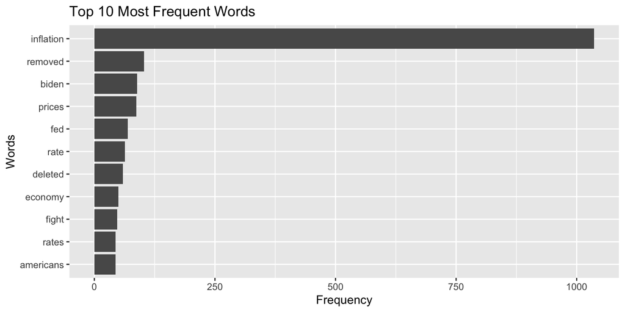

```r
# Plot the top 10 most frequent words
word_counts %>%
  top_n(10) %>%
  ggplot(aes(x = reorder(word, n), y = n)) +
  geom_bar(stat = "identity") +
  coord_flip() +
  labs(title = "Top 10 Most Frequent Words",
       x = "Words",
       y = "Frequency")
```

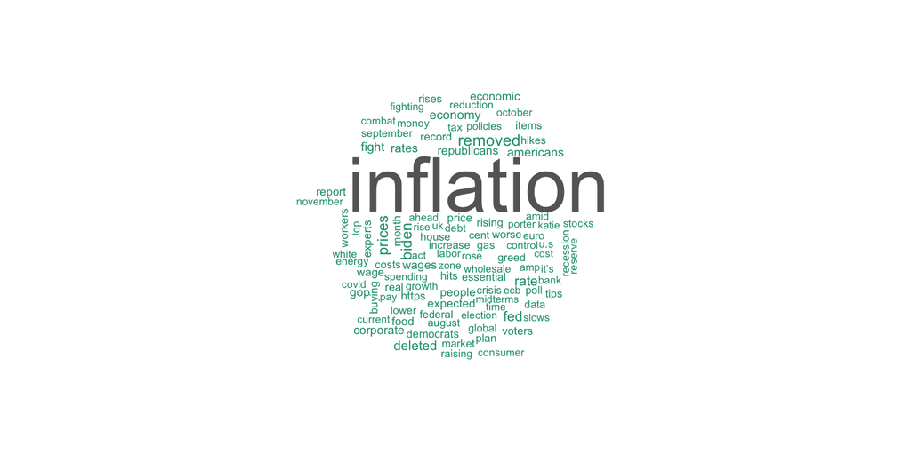

```r
# You can also create a word cloud to visualize word frequency. Larger words indicate higher frequency.
set.seed(381) # for reproducibility, so that you see the same word cloud each time
wordcloud(words = word_counts$word, freq = word_counts$n, max.words = 100, colors = brewer.pal(8, "Dark2"))
```

## Sentiment Analysis

Now, I am going to show you how to perform sentiment analysis on the text data. Sentiment analysis involves quantifying the emotional tone of the text, such as positive, negative, or neutral sentiment.

How do we achieve this goal? One common approach is to use a sentiment lexicon, which is a pre-defined list of words associated with sentiment scores or categories. It is also regarded as a dictionary-based approach, as it feels like you are looking up words in a dictionary to find their sentiment values.

In this tutorial, we will use the AFINN lexicon, which assigns sentiment scores to words ranging from -5 (very negative) to +5 (very positive). Lexicons are pre-defined dictionaries that map words to sentiment scores or categories.

```r
# Use the AFINN lexicon for sentiment analysis
bing_lexicon <- get_sentiments("afinn")

# Note: the first time when you download the lexicon, it may take a while as it fetches the data from the internet. You need to go to your console and type "1" to confirm the download.

# You can also use "bing" (positive OR negative) or "nrc" lexicons (discrete emotion, like fear or joy), depending on your analysis needs. you can explore these lexicons in the tidytext package documentation.

# Join the cleaned data with the Bing lexicon to get sentiment scores
sentiment_data <- cleaned_data %>%
  inner_join(bing_lexicon, by = "word")

# View the sentiment data
head(sentiment_data)
```

```
## # A tibble: 6 × 63
##   id    title thumbnail selftext created_utc author author_created_utc banned_by
##   <chr> <chr> <chr>     <chr>          <dbl> <chr>               <dbl> <lgl>
## 1 xbib… This… default   <NA>      1662902183 rajac…         1655633746 NA
## 2 xcww… Ted … default   [delete…  1663040205 [dele…                 NA NA
## 3 xdhk… Bide… default   <NA>      1663100592 Blesp…         1594404310 NA
## 4 xdhk… Bide… default   <NA>      1663100592 Blesp…         1594404310 NA
## 5 xelk… How … default   <NA>      1663211540 rajac…         1655633746 NA
## 6 xfc7… Use … default   <NA>      1663287076 ----D…         1659404877 NA
## # ℹ 55 more variables: can_mod_post <lgl>, category <lgl>,
## #   content_categories <lgl>, archived <lgl>, discussion_type <lgl>,
## #   distinguished <lgl>, domain <chr>, edited <lgl>, gilded <dbl>,
## #   hidden <lgl>, hide_score <lgl>, is_created_from_ads_ui <lgl>,
## #   is_crosspostable <lgl>, is_meta <lgl>, is_original_content <lgl>,
## #   is_reddit_media_domain <lgl>, is_self <lgl>, is_video <lgl>, locked <lgl>,
## #   media_only <lgl>, name <chr>, no_follow <lgl>, num_comments <dbl>, …
```

```r
# Calculate the overall sentiment score for the text data
overall_sentiment <- sentiment_data %>%
  summarize(total_sentiment = sum(value))
overall_sentiment # negative score indicates overall negative sentiment in the text data.
```

```
## # A tibble: 1 × 1
##   total_sentiment
##             <dbl>
## 1            -625
```

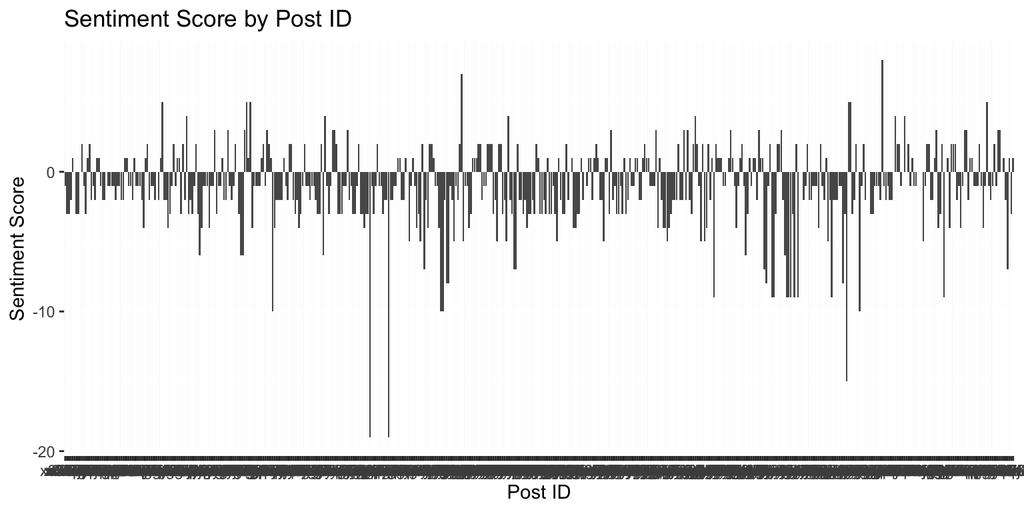

```r
# You can also visualize the sentiment distribution across ids
sentiment_data %>%
  group_by(id) %>%
  summarize(sentiment_score = sum(value)) %>%
  ggplot(aes(x = id, y = sentiment_score)) +
  geom_bar(stat = "identity") +
  labs(title = "Sentiment Score by Post ID",
       x = "Post ID",
       y = "Sentiment Score")
```

```r
# RQ: Which post has the highest positive sentiment score? Which has the most negative sentiment score?

# most positive
sentiment_data %>%
  group_by(id) %>%
  summarize(sentiment_score = sum(value)) %>%
  arrange(desc(sentiment_score)) %>% # descending order of sentiment score so that the largest number comes first
  head(1) # highest positive sentiment score
```

```
## # A tibble: 1 × 2
##   id     sentiment_score
##   <chr>            <dbl>
## 1 yw6e4n               8
```

```r
# most negative
sentiment_data %>%
  group_by(id) %>%
  summarize(sentiment_score = sum(value)) %>%
  arrange(sentiment_score) %>%
  head(1) # most negative sentiment score
```

```
## # A tibble: 1 × 2
##   id     sentiment_score
##   <chr>            <dbl>
## 1 xosul5             -19
```

## Topic Modeling (LDA)

Finally, we will explore topic modeling, which is a technique used to discover hidden topics in a collection of documents. One common approach is Latent Dirichlet Allocation (LDA), which assumes that each document is a mixture of topics and each topic is a mixture of words.

For each word, it has a probability to appear in a document, and also a probability to belong to a topic. When we observe the words in documents, we can infer the topics based on the patterns of word co-occurrence. [We are going to skip the mathematical details for now, but you can refer to the book “Text Mining with R” for more information.]

Therefore, to conduct LDA topic modeling, we first need to create a Document-Term Matrix (DTM) from the cleaned text data. A DTM is a matrix where rows represent documents, columns represent terms (words), and the values indicate the frequency of each term in each document.

```r
# Create a Document-Term Matrix (DTM) from the cleaned data
dtm <- cleaned_data %>%
  count(id, word) %>%
  cast_dtm(document = id, term = word, value = n)

# In this analysis, documents are individual Reddit posts. In this function execution, id is the document identifier, word is the term, and n is the frequency of the term in the document. Remember the `id` column comes from the original dataset, which identifies each Reddit post uniquely. In this analysis, documents are individual Reddit posts.

# View the DTM output
dtm
```

```
## <<DocumentTermMatrix (documents: 943, terms: 2658)>>
## Non-/sparse entries: 8658/2497836
## Sparsity           : 100%
## Maximal term length: 45
## Weighting          : term frequency (tf)
```

Now that we have the DTM, we can fit an LDA model to discover topics in the text data.

```r
# Fit an LDA model with 5 topics
lda_model <- LDA(dtm, k = 5, control = list(seed = 381))
# dtm is the document-term matrix we created earlier
# k = number of topics; you can adjust this number based on your analysis needs. We are going to skip the parameter tuning for today.
# control = list(seed = 381) is to ensure reproducibility; otherwise you will have different outputs each time you run the model.

# View the top terms in each topic
lda_topics <- tidy(lda_model, matrix = "beta")
top_terms <- lda_topics %>%
  group_by(topic) %>%
  top_n(10, beta) %>%
  ungroup() %>%
  arrange(topic, -beta)
# Print the top terms for each topic
top_terms
```

```
## # A tibble: 50 × 3
##    topic term        beta
##    <int> <chr>      <dbl>
##  1     1 inflation 0.103
##  2     1 rate      0.0283
##  3     1 prices    0.0234
##  4     1 expected  0.0181
##  5     1 fight     0.0152
##  6     1 uk        0.0113
##  7     1 month     0.0111
##  8     1 hikes     0.0108
##  9     1 costs     0.0107
## 10     1 august    0.0103
## # ℹ 40 more rows
```

How to read this output? Each topic is represented by a set of terms with associated beta values, which indicate the importance of each term within that topic. Higher beta values mean that the term is more representative of the topic. Usually, researchers interpret the topics based on the top terms associated with them.

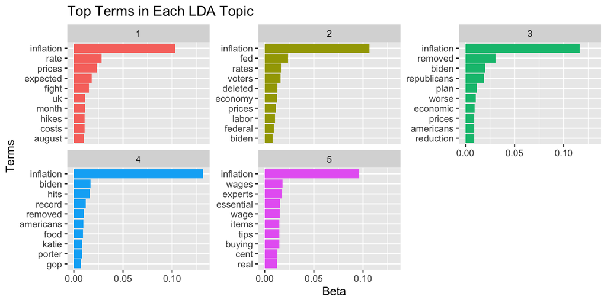

```r
# You can visualize the top terms for each topic using ggplot2
top_terms %>%
  mutate(term = reorder_within(term, beta, topic)) %>%
  ggplot(aes(x = term, y = beta, fill = factor(topic))) +
  geom_bar(stat = "identity", show.legend = FALSE) +
  facet_wrap(~ topic, scales = "free_y") +
  coord_flip() +
  scale_x_reordered() +
  labs(title = "Top Terms in Each LDA Topic",
       x = "Terms",
       y = "Beta")
```

## Extended Learning: Topic Modeling (STM)

Since we now have some basic understanding of topic modeling using LDA, let’s explore Structural Topic Modeling (STM). STM is an advanced topic modeling technique that allows for the inclusion of document-level metadata (covariates) in the modeling process. This enables researchers to explore how topics vary across different document characteristics.

STM is one of the most widely used topic modeling variants. Its key innovation is incorporating corpus metadata (e.g., time, author, publication outlet) into the topic model.

What research questions can STM answer?

In the social science domain, STM has been applied across multiple empirical contexts, including but not limited to: (1) analyzing topics or frames in mass media publications, historical documents, and policy materials; (2) examining open-ended survey responses to measure citizen opinion; and (3) studying public opinion using social media data.

The key goal of the STM is to allow researchers to discover latent topics while estimating their relationships with the metadata. As a result, STM enables not only descriptive questions about what themes are present in a corpus, but also inferential hypothesis testing regarding how topics vary across metadata attributes.

```r
# prepare metadata for STM
stm_processed <- textProcessor(processed_data$full_text,
                              metadata = processed_data,
                              lowercase = TRUE,
                              striphtml = TRUE)
```

```
## Building corpus...
## Converting to Lower Case...
## Removing punctuation...
## Removing stopwords...
## Removing numbers...
## Stemming...
## Creating Output...
```

```r
stm_processed # view the processed output
```

```
## A text corpus with 943 documents, and an 2282 word dictionary.
```

```r
# prepare documents for STM
out <- prepDocuments(stm_processed$documents, stm_processed$vocab,
                     stm_processed$meta, lower.thresh = 20)
```

```
## Removing 2211 of 2282 terms (6247 of 9758 tokens) due to frequency
## Removing 6 Documents with No Words
## Your corpus now has 937 documents, 71 terms and 3511 tokens.
```

```r
# run STM with 5 topics, including 'score' as a covariate
stm_model <- stm(documents = out$documents,
                 vocab = out$vocab,
                 K = 5,
                 prevalence = ~ score,
                 data = as.data.frame(out$meta),
                 max.em.its = 75,
                 seed = 381)
```

[output not shown]

[output cut: 56 more lines]

```
## Completed M-Step.
## Completing Iteration 19 (approx. per word bound = -3.523, relative change = 3.027e-05)
## ........................................................................................................
## Completed E-Step (0 seconds).
## Completed M-Step.
## Completing Iteration 20 (approx. per word bound = -3.523, relative change = 1.728e-05)
## Topic 1: remov, biden, say, american, expect
##  Topic 2: inflat, price, will, economi, republican
##  Topic 3: wage, democrat, high, buy, get
##  Topic 4: rate, inflat, high, fed, rise
##  Topic 5: inflat, delet, corpor, year, new
## ........................................................................................................
## Completed E-Step (0 seconds).
## Completed M-Step.
## Model Converged
```

```r
# what is vocab? Vocab is the vocabulary of unique terms in the corpus. In the context of STM, it refers to the set of words that are used to represent the documents in the model. The vocab parameter is essential for defining the terms that will be analyzed and associated with topics.

# View the top terms in each topic
stm_topics <- tidy(stm_model)
top_stm_terms <- stm_topics %>%
  group_by(topic) %>%
  top_n(10, beta) %>%
  ungroup() %>%
  arrange(topic, -beta)
# Print the top terms for each topic
top_stm_terms
```

```
## # A tibble: 50 × 3
##    topic term       beta
##    <int> <chr>     <dbl>
##  1     1 remov    0.191
##  2     1 biden    0.184
##  3     1 say      0.149
##  4     1 american 0.0936
##  5     1 expect   0.0680
##  6     1 food     0.0588
##  7     1 stock    0.0514
##  8     1 polici   0.0496
##  9     1 eas      0.0404
## 10     1 fight    0.0395
## # ℹ 40 more rows
```

Since we do not have time to go into details of STM, I encourage you to explore the STM package documentation and the original paper by Roberts et al. (2014) for a deeper understanding of the methodology and its applications. For a more detailed tutorial to practice on STM, see [J381 Textbook chapter on STM](https://jolukito.quarto.pub/j381m-textbook/94-stm.html).